The format of this lab follows the same format as the previous ones. Your goal is to predict the value of the third column (which will be missing on the test set) using the techniques we have learned so far.

For this lab, please only use neural networks.

# Set up

Read in the following libraries and to load the crimes dataset:

```r
library(readr)
library(dplyr)
```

```r
library(ggplot2)
library(viridis)
library(keras)
crimes <- read_csv("https://statsmaths.github.io/ml_data/chi_crimes_12.csv")
```

```
## `curl` package not installed, falling back to using `url()`
```

The names of the crimes are, in order:

```r
crimes_list <- c("theft", "battery", "criminal damage", "narcotics",
"other offense", "assault", "burglary", "motor vehicle theft", "robbery",
"deceptive practice", "criminal trespass", "prostitution")
```

Make sure your predictions are all an integer from 1 to 12.

# Lab 11

Setting up matrices to store our data

```r
X <- scale(as.matrix(select(crimes, latitude, longitude, hour)))
X_train <- X[crimes$train_id == "train",]
X_valid <- X[crimes$train_id == "valid",]

y <- crimes$crime_type - 1
y_train <- to_categorical(y[crimes$train_id == "train"], num_classes = 12)
y_valid <- to_categorical(y[crimes$train_id == "valid"], num_classes = 12)
```

```r
model1 <- keras_model_sequential()
model1 %>%
  layer_dense(units = 64, input_shape = c(3)) %>%
  layer_activation(activation = "relu") %>%
  layer_dense(units = 64) %>%
  layer_activation(activation = "relu") %>%
  layer_dense(units = 12) %>%
  layer_activation(activation = "softmax")
model1
```

```
## Model
## ___________________________________________________________________________
## Layer (type)                     Output Shape                  Param #
## ===========================================================================
## dense_1 (Dense)                  (None, 64)                    256
## ___________________________________________________________________________
## activation_1 (Activation)        (None, 64)                    0
## ___________________________________________________________________________
## dense_2 (Dense)                  (None, 64)                    4160
## ___________________________________________________________________________
## activation_2 (Activation)        (None, 64)                    0
## ___________________________________________________________________________
## dense_3 (Dense)                  (None, 12)                    780
## ___________________________________________________________________________
## activation_3 (Activation)        (None, 12)                    0
## ===========================================================================
## Total params: 5,196
## Trainable params: 5,196
## Non-trainable params: 0
## ___________________________________________________________________________
```

Compiling and fitting the model, plotting how accuracy and loss as each epoch progresses. Some observations include: -As I increase my learning rate, I need a fewer number of epochs but the validation predictions tend not to be as good if my learning rate is too high. Therefore, in the interest of time, I found that the learning rate and epochs below resulted in a good tradeoff between the two. -Another thing I played around with was the optimizer functions: I found that adagrad and rmsprop tended to do better with the data.

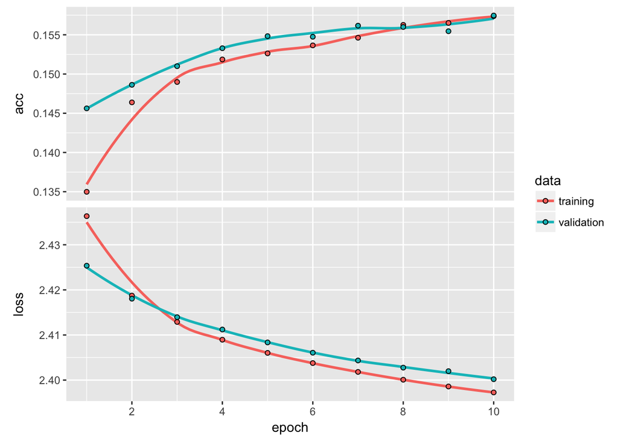

```r
model1 %>% compile(loss = 'categorical_crossentropy',
                  optimizer = optimizer_adagrad(lr=0.01),
                  metrics = c('accuracy'))

history <- model1 %>% fit(
  X_train, y_train,
  epochs = 10,
  validation_data = list(X_valid, y_valid)
)

plot(history)
```

Finally, I save my predicted values

```r
crimes$crime_type_pred <- predict_classes(model1, x = X) + 1
```

# Submission

The code below assumes that you have added a prediction named `crime_type_pred` to every row of the dataset.

```r
submit <- select(crimes, obs_id, crime_type_pred)
write_csv(submit, "class11_submit.csv")
```

Now, upload this file (ends with “.Rmd”), the HTML output (ends with “.nb.html” or “.html”), and the csv file to GitHub.